# 13_AROC_from_graph

## 13_AROC_from_graph

#### Question

1. This question is about average rate of change. For function $f(x)$, its average rate of change between $x=a$ and $x=b$ equals a quotient of differences:
   $$\text{ave rate of change} = \frac{f(b)-f(a)}{b-a}$$

   A function $f$ is graphed below.

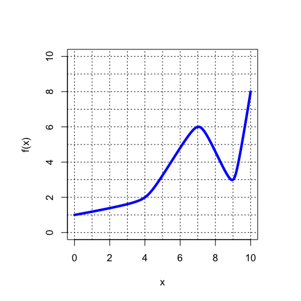

   - Find the average rate of change between $x=4$ and $x=7$.

   *You can round to the nearest hundredth.*

#### Question

2. This question is about average rate of change. For function $f(x)$, its average rate of change between $x=a$ and $x=b$ equals a quotient of differences:
   $$\text{ave rate of change} = \frac{f(b)-f(a)}{b-a}$$

   A function $f$ is graphed below.

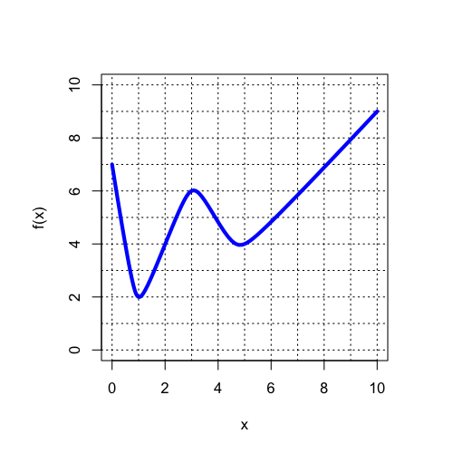

   - Find the average rate of change between $x=0$ and $x=3$.

   *You can round to the nearest hundredth.*

#### Question

3. This question is about average rate of change. For function $f(x)$, its average rate of change between $x=a$ and $x=b$ equals a quotient of differences:
   $$\text{ave rate of change} = \frac{f(b)-f(a)}{b-a}$$

   A function $f$ is graphed below.

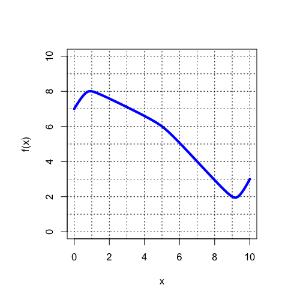

   - Find the average rate of change between $x=0$ and $x=9$.

   *You can round to the nearest hundredth.*

#### Question

4. This question is about average rate of change. For function $f(x)$, its average rate of change between $x=a$ and $x=b$ equals a quotient of differences:
   $$\text{ave rate of change} = \frac{f(b)-f(a)}{b-a}$$

   A function $f$ is graphed below.

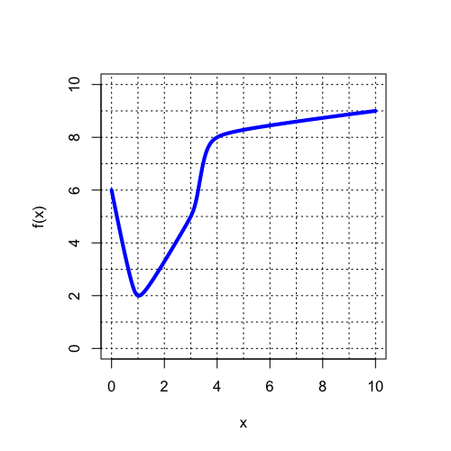

   - Find the average rate of change between $x=4$ and $x=10$.

   *You can round to the nearest hundredth.*

#### Question

5. This question is about average rate of change. For function $f(x)$, its average rate of change between $x=a$ and $x=b$ equals a quotient of differences:
   $$\text{ave rate of change} = \frac{f(b)-f(a)}{b-a}$$

   A function $f$ is graphed below.

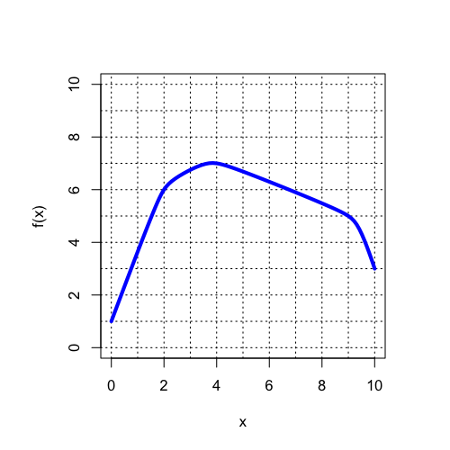

   - Find the average rate of change between $x=2$ and $x=4$.

   *You can round to the nearest hundredth.*

#### Question

6. This question is about average rate of change. For function $f(x)$, its average rate of change between $x=a$ and $x=b$ equals a quotient of differences:
   $$\text{ave rate of change} = \frac{f(b)-f(a)}{b-a}$$

   A function $f$ is graphed below.

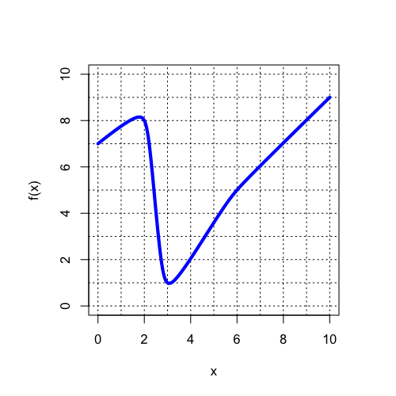

   - Find the average rate of change between $x=0$ and $x=3$.

   *You can round to the nearest hundredth.*

#### Question

7. This question is about average rate of change. For function $f(x)$, its average rate of change between $x=a$ and $x=b$ equals a quotient of differences:
   $$\text{ave rate of change} = \frac{f(b)-f(a)}{b-a}$$

   A function $f$ is graphed below.

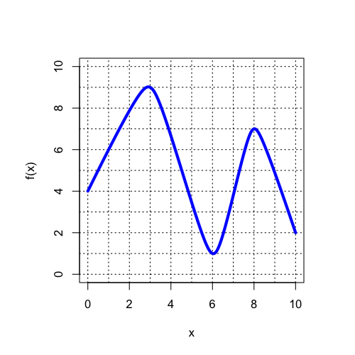

   - Find the average rate of change between $x=0$ and $x=8$.

   *You can round to the nearest hundredth.*

#### Question

8. This question is about average rate of change. For function $f(x)$, its average rate of change between $x=a$ and $x=b$ equals a quotient of differences:
   $$\text{ave rate of change} = \frac{f(b)-f(a)}{b-a}$$

   A function $f$ is graphed below.

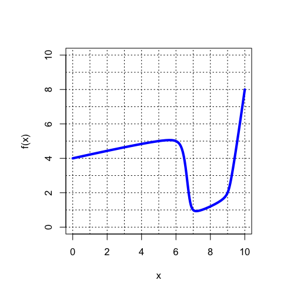

   - Find the average rate of change between $x=9$ and $x=10$.

   *You can round to the nearest hundredth.*